# Heart Data

Gözde Nur Özdemir

2023-08-28

# HEART DISEASE DATA SET

You can find the data from [here](https://www.kaggle.com/datasets/fedesoriano/heart-failure-prediction)

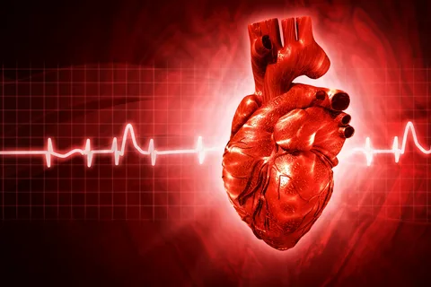

### Preperation

```r
# Please first download required library
library(tidyverse)
library(ggplot2)
library(dplyr)
library(rvest)
library(stringr)
library(corrplot)
```

### General Information About Data Set

```r
dt<-read.csv("C:/Users/gozde/Desktop/Heart Data/heart.csv")
dt$HeartDisease<-ifelse(dt$HeartDisease==0,"No Heart Disease","Yes Heart Disease")
dt$HeartDisease<-factor(dt$HeartDisease)
dt$Sex<-factor(dt$Sex)
dt$ExerciseAngina<-ifelse(dt$ExerciseAngina=="N","No","Yes")
dt$ExerciseAngina<-factor(dt$ExerciseAngina)
dt$RestingECG<-factor(dt$RestingECG)
dt$ST_Slope<-factor(dt$ST_Slope)
dt$ChestPainType<-factor(dt$ChestPainType)
summary(dt)
```

```
##       Age        Sex     ChestPainType   RestingBP      Cholesterol
##  Min.   :28.00   F:193   ASY:496       Min.   :  0.0   Min.   :  0.0
##  1st Qu.:47.00   M:725   ATA:173       1st Qu.:120.0   1st Qu.:173.2
##  Median :54.00           NAP:203       Median :130.0   Median :223.0
##  Mean   :53.51           TA : 46       Mean   :132.4   Mean   :198.8
##  3rd Qu.:60.00                         3rd Qu.:140.0   3rd Qu.:267.0
##  Max.   :77.00                         Max.   :200.0   Max.   :603.0
##    FastingBS       RestingECG      MaxHR       ExerciseAngina    Oldpeak
##  Min.   :0.0000   LVH   :188   Min.   : 60.0   No :547        Min.   :-2.6000
##  1st Qu.:0.0000   Normal:552   1st Qu.:120.0   Yes:371        1st Qu.: 0.0000
##  Median :0.0000   ST    :178   Median :138.0                  Median : 0.6000
##  Mean   :0.2331                Mean   :136.8                  Mean   : 0.8874
##  3rd Qu.:0.0000                3rd Qu.:156.0                  3rd Qu.: 1.5000
##  Max.   :1.0000                Max.   :202.0                  Max.   : 6.2000
##  ST_Slope              HeartDisease
##  Down: 63   No Heart Disease :410
##  Flat:460   Yes Heart Disease:508
##  Up  :395
##
##
##
```

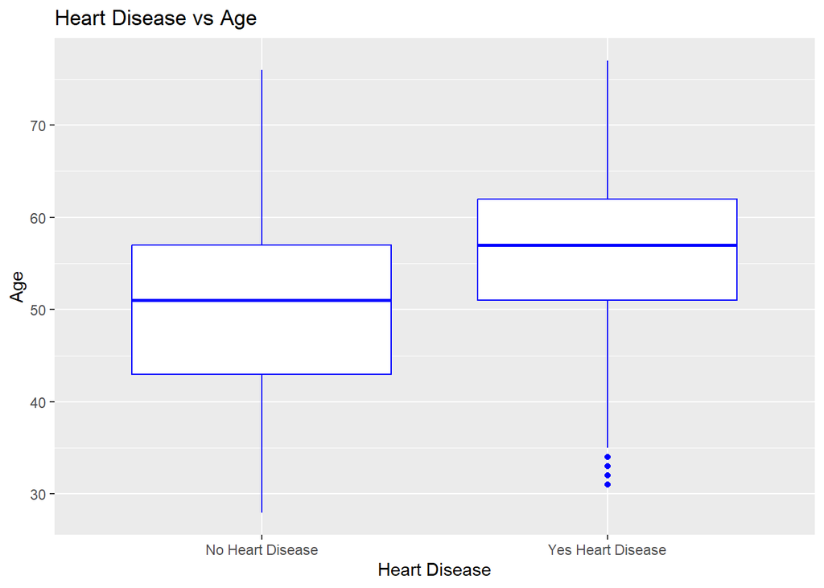

```r
plot1 <- ggplot(data = dt, aes(x = HeartDisease, y = Age)) +
  geom_boxplot(col="blue") +
  labs(x = "Heart Disease", y = "Age", title = "Heart Disease vs Age")

plot1
```

As we can see from the plot 1, if median age are higher, people tend to have heart disease.

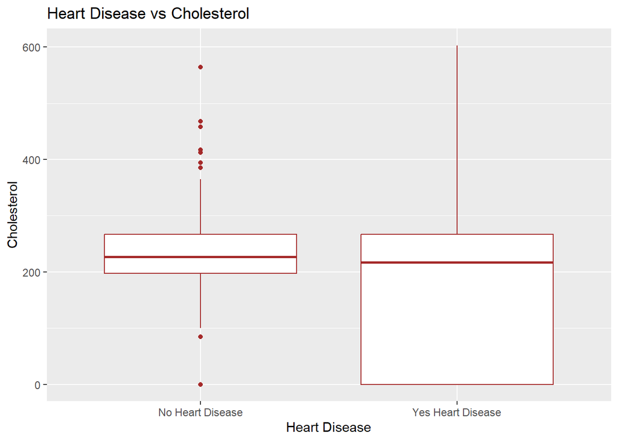

```r
plot2 <- ggplot(data = dt, aes(x = HeartDisease, y = Cholesterol)) +
  geom_boxplot(col="brown") +
  labs(x = "Heart Disease", y = "Cholesterol", title = "Heart Disease vs Cholesterol")
plot2
```

If people have heart disease their cholesterol’s IQR are longer and its median is smaller.

### Logistic Regression

#### Heart Disease and Cholesterol

```r
dt$HeartDisease<-ifelse(dt$HeartDisease=="Yes Heart Disease",1,0)
dt$HeartDisease<-factor(dt$HeartDisease)
logistic<-glm(data=dt,formula=HeartDisease~Cholesterol,family = binomial)
summary(logistic)
```

```
##
## Call:
## glm(formula = HeartDisease ~ Cholesterol, family = binomial,
##     data = dt)
##
## Deviance Residuals:
##     Min       1Q   Median       3Q      Max
## -1.6904  -1.2030   0.7401   1.1297   1.9063
##
## Coefficients:
##              Estimate Std. Error z value Pr(>|z|)
## (Intercept)  1.154892   0.156934   7.359 1.85e-13 ***
## Cholesterol -0.004634   0.000679  -6.826 8.75e-12 ***
## ---
## Signif. codes:  0 '***' 0.001 '**' 0.01 '*' 0.05 '.' 0.1 ' ' 1
##
## (Dispersion parameter for binomial family taken to be 1)
##
##     Null deviance: 1262.1  on 917  degrees of freedom
## Residual deviance: 1210.3  on 916  degrees of freedom
## AIC: 1214.3
##
## Number of Fisher Scoring iterations: 4
```

```r
# log1<-1.15+(-0.0046)*cholesterol
```

As we can understand from log1 if cholesterol level increases 1 unit then heart disease’s rate decreases as 0.0046.

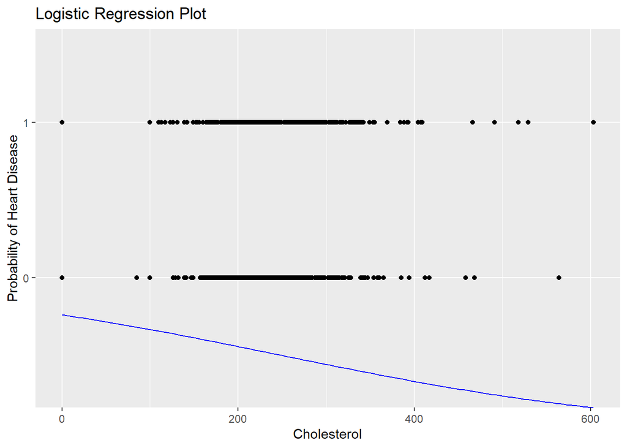

```r
df_pred <- data.frame(Cholesterol = seq(min(dt$Cholesterol), max(dt$Cholesterol), length.out=100))
df_pred$prob <- predict(logistic, newdata=df_pred, type="response")
ggplot(dt, aes(x=Cholesterol, y=HeartDisease)) +
  geom_point() +
  geom_line(data=df_pred, aes(x=Cholesterol, y=prob), color="blue") +
  ylab("Probability of Heart Disease") +
  xlab("Cholesterol") +
  ggtitle("Logistic Regression Plot")
```

Here is the graph.

#### Heart Disease and Age

```r
logistic1<-glm(data=dt,formula=HeartDisease~Age,family = binomial)
summary(logistic1)
```

```
##
## Call:
## glm(formula = HeartDisease ~ Age, family = binomial, data = dt)
##
## Deviance Residuals:
##     Min       1Q   Median       3Q      Max
## -1.9224  -1.1722   0.7589   1.0170   1.7191
##
## Coefficients:
##             Estimate Std. Error z value Pr(>|z|)
## (Intercept) -3.21308    0.42001  -7.650 2.01e-14 ***
## Age          0.06434    0.00780   8.248  < 2e-16 ***
## ---
## Signif. codes:  0 '***' 0.001 '**' 0.01 '*' 0.05 '.' 0.1 ' ' 1
##
## (Dispersion parameter for binomial family taken to be 1)
##
##     Null deviance: 1262.1  on 917  degrees of freedom
## Residual deviance: 1186.7  on 916  degrees of freedom
## AIC: 1190.7
##
## Number of Fisher Scoring iterations: 4
```

```r
# log2<-(-3.21)+0.064*(age)
```

This is invalid since age can’t be negative value but it’s intercept is -3.21.

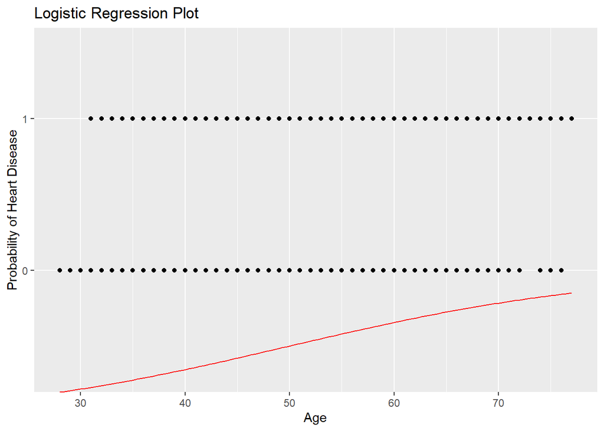

```r
df_pred <- data.frame(Age = seq(min(dt$Age), max(dt$Age), length.out=100))
df_pred$prob <- predict(logistic1, newdata=df_pred, type="response")
ggplot(dt, aes(x=Age, y=HeartDisease)) +
  geom_point() +
  geom_line(data=df_pred, aes(x=Age, y=prob), color="red") +
  ylab("Probability of Heart Disease") +
  xlab("Age") +
  ggtitle("Logistic Regression Plot")
```

Here is the graph.

#### Heart Disease and FastingBS

```r
logistic2<-glm(data=dt,formula=HeartDisease~FastingBS,family = binomial)
summary(logistic2)
```

```
##
## Call:
## glm(formula = HeartDisease ~ FastingBS, family = binomial, data = dt)
##
## Deviance Residuals:
##     Min       1Q   Median       3Q      Max
## -1.7786  -1.1438   0.6785   1.2114   1.2114
##
## Coefficients:
##             Estimate Std. Error z value Pr(>|z|)
## (Intercept) -0.07959    0.07544  -1.055    0.291
## FastingBS    1.43120    0.18520   7.728  1.1e-14 ***
## ---
## Signif. codes:  0 '***' 0.001 '**' 0.01 '*' 0.05 '.' 0.1 ' ' 1
##
## (Dispersion parameter for binomial family taken to be 1)
##
##     Null deviance: 1262.1  on 917  degrees of freedom
## Residual deviance: 1192.3  on 916  degrees of freedom
## AIC: 1196.3
##
## Number of Fisher Scoring iterations: 4
```

```r
# log3<-(-0.07959)+ 1.43120*FastingBS
```

So if fastingBS increase 1 unit than heart disease’s rate also increases as 1.43120.

#### Heart Disease and Sex

```r
dt$Sex<-relevel(dt$Sex,"M")
logistic3<-glm(data=dt,formula=HeartDisease~Sex,family = binomial)
summary(logistic3)
```

```
##
## Call:
## glm(formula = HeartDisease ~ Sex, family = binomial, data = dt)
##
## Deviance Residuals:
##     Min       1Q   Median       3Q      Max
## -1.4135  -1.4135   0.9584   0.9584   1.6436
##
## Coefficients:
##             Estimate Std. Error z value Pr(>|z|)
## (Intercept)   0.5396     0.0770   7.008 2.41e-12 ***
## SexF         -1.5904     0.1814  -8.766  < 2e-16 ***
## ---
## Signif. codes:  0 '***' 0.001 '**' 0.01 '*' 0.05 '.' 0.1 ' ' 1
##
## (Dispersion parameter for binomial family taken to be 1)
##
##     Null deviance: 1262.1  on 917  degrees of freedom
## Residual deviance: 1175.0  on 916  degrees of freedom
## AIC: 1179
##
## Number of Fisher Scoring iterations: 4
```

```r
# log3<-(0.5396)-(1.5904)*Female
```

Interpreting the coefficient, we can say that being female (SexF = 1) lowers the logarithm of the odds of heart disease by 1.5904 units compared to being male (SexF = 0).

#### Heart Disease and Exercise Angina

```r
dt$ExerciseAngina<-relevel(dt$ExerciseAngina,"No")
logistic4<-glm(data=dt,formula=HeartDisease~ExerciseAngina,family = binomial)
summary(logistic4)
```

```
##
## Call:
## glm(formula = HeartDisease ~ ExerciseAngina, family = binomial,
##     data = dt)
##
## Deviance Residuals:
##     Min       1Q   Median       3Q      Max
## -1.9539  -0.9299   0.5665   0.5665   1.4470
##
## Coefficients:
##                   Estimate Std. Error z value Pr(>|z|)
## (Intercept)       -0.61462    0.08958  -6.861 6.84e-12 ***
## ExerciseAnginaYes  2.36303    0.17138  13.788  < 2e-16 ***
## ---
## Signif. codes:  0 '***' 0.001 '**' 0.01 '*' 0.05 '.' 0.1 ' ' 1
##
## (Dispersion parameter for binomial family taken to be 1)
##
##     Null deviance: 1262.1  on 917  degrees of freedom
## Residual deviance: 1020.4  on 916  degrees of freedom
## AIC: 1024.4
##
## Number of Fisher Scoring iterations: 4
```

```r
# logit3 = -0.61462 + 2.36303 * ExerciseAnginaYes
```

#### Heart Disease and Depression

```r
logistic5<-glm(data=dt,formula=HeartDisease~Oldpeak,family = binomial)
summary(logistic5)
```

```
##
## Call:
## glm(formula = HeartDisease ~ Oldpeak, family = binomial, data = dt)
##
## Deviance Residuals:
##     Min       1Q   Median       3Q      Max
## -2.7147  -0.9472   0.4066   0.9980   2.5404
##
## Coefficients:
##             Estimate Std. Error z value Pr(>|z|)
## (Intercept) -0.56890    0.09367  -6.073 1.25e-09 ***
## Oldpeak      1.00672    0.08905  11.305  < 2e-16 ***
## ---
## Signif. codes:  0 '***' 0.001 '**' 0.01 '*' 0.05 '.' 0.1 ' ' 1
##
## (Dispersion parameter for binomial family taken to be 1)
##
##     Null deviance: 1262.1  on 917  degrees of freedom
## Residual deviance: 1088.5  on 916  degrees of freedom
## AIC: 1092.5
##
## Number of Fisher Scoring iterations: 4
```

```r
# log4<-(-0.5689)+(1.00672)*(Depression)
```

When depression level increases 1 unit then heart disease’s rate increases as 1.00672

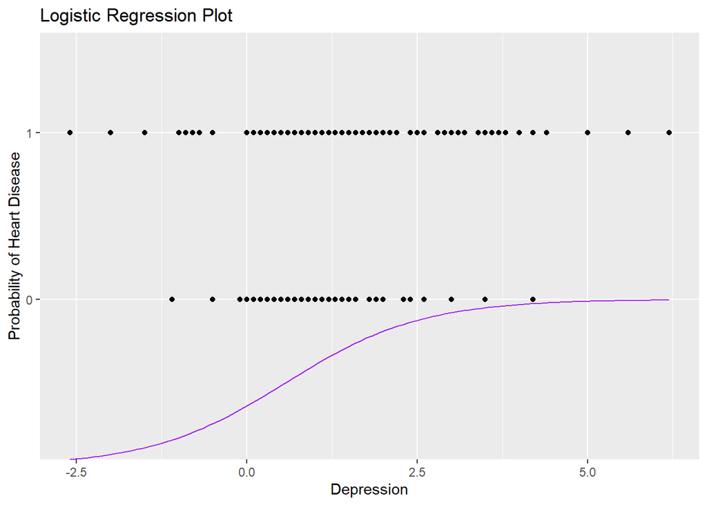

```r
df_pred <- data.frame(Oldpeak = seq(min(dt$Oldpeak), max(dt$Oldpeak), length.out=100))
df_pred$prob <- predict(logistic5, newdata=df_pred, type="response")
ggplot(dt, aes(x=Oldpeak, y=HeartDisease)) +
  geom_point() +
  geom_line(data=df_pred, aes(x=Oldpeak, y=prob), color="purple") +
  ylab("Probability of Heart Disease") +
  xlab("Depression") +
  ggtitle("Logistic Regression Plot")
```

Here is the graph.